# Data Visualization with ggplot2

July 14, 2019

## Why do we visualize?

- to get better understanding of the data.
- to understand relationship between variables.
- to help discovering insights.

## How to visualize in R?

- basic R plot
- ggplot2

## What is ggplot2?

- [ggplot2](https://ggplot2.tidyverse.org/) is a library for declaratively creating graphics
- it is based on The Grammar of Graphics.
  - Grammar of Graphics is a concept that defines a plot as a set of component layers: **aesthetic and geometry**.
  - You **provide the data**, tell ggplot2 how to map variables to **aesthetics**, what graphical **geometries** to use, and it takes care of the details.

## Grammar of Graphic

A plot is basically a stack of layers consisting of:

- data
- aesthetic –> aes()
- geometry –> geom_
- theme –> theme()

## Take a look at this plot

A scatter plot of `mtcars` data with x and y axes are mapped to `wt` and `mpg` columns, respectively.

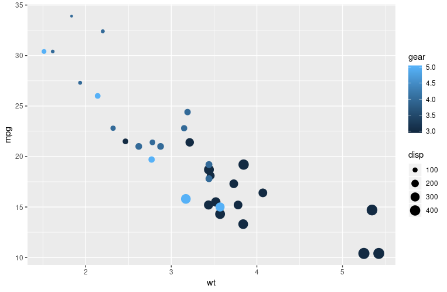

## Now, look at the graphic in a ‘Grammar of Graphics’ way.

A plot is just a blank canvas

[figure not shown]

## Now, look at the graphic in a ‘Grammar of Graphics’ way.

A plot is just a blank canvas + aesthetic

[figure not shown]

## Now, look at the graphic in a ‘Grammar of Graphics’ way.

A plot is just a blank canvas + aesthetic + geometry

[figure not shown]

## Now, look at the graphic in a ‘Grammar of Graphics’ way.

A plot is just a blank canvas + aesthetic + geometry + more aesthetics

[figure not shown]

## Now, look at the graphic in a ‘Grammar of Graphics’ way.

A plot is just a blank canvas + aesthetic + geometry + more aesthetics + labels

[figure not shown]

## Translate the Grammar of Graphics to ggplot

A plot is just a blank canvas

```r
  ggplot(mtcars)
```

[figure not shown]

## Translate the Grammar of Graphics to ggplot

A plot is just a blank canvas + aesthetic

```r
  ggplot(mtcars, aes(x = wt, y = mpg))
```

[figure not shown]

## Translate the Grammar of Graphics to ggplot

```r
  ggplot(mtcars, aes(x = wt, y = mpg, size = disp, color = gear)) +
  geom_point()
```

[figure not shown]

## Translate the Grammar of Graphics to ggplot

A plot is just a blank canvas + aesthetic + geometry + more aesthetics

```r
  ggplot(mtcars, aes(x = wt, y = mpg, size = disp, color = gear)) +
  geom_point()
```

[figure not shown]

## Translate the Grammar of Graphics to ggplot

A plot is just a blank canvas + aesthetic + geometry + more aesthetics + labels

```r
  ggplot(mtcars, aes(x = wt, y = mpg, size = disp, color = gear)) +
  geom_point() +
  labs(title = "The miles/gallon spent based on the weight of the cars")
```

[figure not shown]

## Drawing your first plot

### Preparation

- Make sure you have the library installed on your machine:

  ```r
    install.packages('ggplot2')
  ```

- load the ggplot library:

  ```r
   library(ggplot2)
  ```

- use the dataset [`mtcars`](https://stat.ethz.ch/R-manual/R-devel/library/datasets/html/mtcars.html), available in R Studio.
  - explore its structure:

  ```r
    str(mtcars)
  ```

Now replicate this script on your own machine.

```r
  library(ggplot2)

  ggplot(mtcars, aes(x = wt, y = mpg, size = disp, color = gear)) +
    geom_point() +
    geom_smooth()
    labs(title = "The miles/gallon spent based on the weight of the cars")
```

Notice that we add layers using the symbol `+`.

Your output should look like this:

[figure not shown]

## Playing with geoms

Spend your time playing with different types of geoms by just simply changing the geom from the example that we have created earlier.

### geom_bar

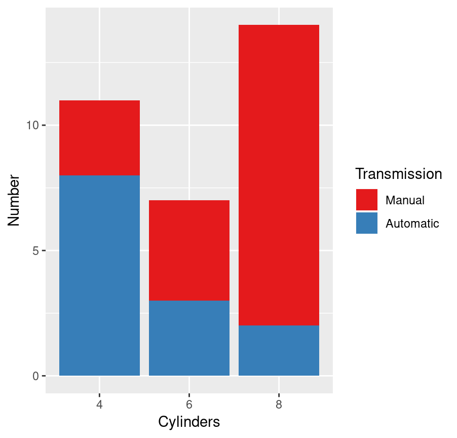

```r
library(ggplot2)
ggplot(mtcars, aes(x = factor(cyl),
                   fill = factor(am))) +
  # try position = 'dodge', 'fill'
  geom_bar(position = 'stack') +
  scale_x_discrete('Cylinders') +
  scale_y_continuous('Number') +
  scale_fill_manual('Transmission',
    values = c("#E41A1C", "#377EB8"),
    labels = c("Manual", "Automatic"))
```

### histogram

#### 1 - Make a univariate histogram

```r
ggplot(mtcars, aes(x = mpg)) +
  geom_histogram()
```

#### 2 - Plot 1, plus set binwidth to 1 in the geom layer

```r
ggplot(mtcars, aes(x = mpg)) +
  geom_histogram(binwidth = 1)
```

#### 3 - Plot 2, plus MAP ..density.. to the y aesthetic (i.e. in a second aes() function)

```r
ggplot(mtcars, aes(x = mpg)) +
  geom_histogram(binwidth = 1, aes(y = ..density..))
```

#### 4 - plot 3, plus SET the fill attribute to “#377EB8”

```r
ggplot(mtcars, aes(x = mpg)) +
  geom_histogram(binwidth = 1, fill = "#377EB8", aes(y = ..density..))
```

## Playing with aesthetics

#### Basic scatter plot: wt on x-axis and mpg on y-axis; map cyl to col

```r
ggplot(mtcars, aes(x=wt, y=mpg, color=cyl)) + geom_point(size=4)
```

#### Hollow circles

```r
ggplot(mtcars, aes(x=wt, y=mpg, color=cyl)) + geom_point(size=4, shape=1)
```

#### Add transparency

```r
ggplot(mtcars, aes(x=wt, y=mpg, color=cyl)) + geom_point(size=4, shape=1, alpha=0.6)
```

## Playing with facet

- Facet = splitting a plot into several subplots.
- Let’s play using the [`iris`](https://rpubs.com/moeransm/intro-iris) dataset.
- Let’s take a brief look into the dataset

```r
  str(iris)
```

```
## 'data.frame':    150 obs. of  5 variables:
##  $ Sepal.Length: num  5.1 4.9 4.7 4.6 5 5.4 4.6 5 4.4 4.9 ...
##  $ Sepal.Width : num  3.5 3 3.2 3.1 3.6 3.9 3.4 3.4 2.9 3.1 ...
##  $ Petal.Length: num  1.4 1.4 1.3 1.5 1.4 1.7 1.4 1.5 1.4 1.5 ...
##  $ Petal.Width : num  0.2 0.2 0.2 0.2 0.2 0.4 0.3 0.2 0.2 0.1 ...
##  $ Species     : Factor w/ 3 levels "setosa","versicolor",..: 1 1 1 1 1 1 1 1 1 1 ...
```

```r
  names(iris)
```

```
## [1] "Sepal.Length" "Sepal.Width"  "Petal.Length" "Petal.Width"
## [5] "Species"
```

## Playing with facet

Now, let’s start playing

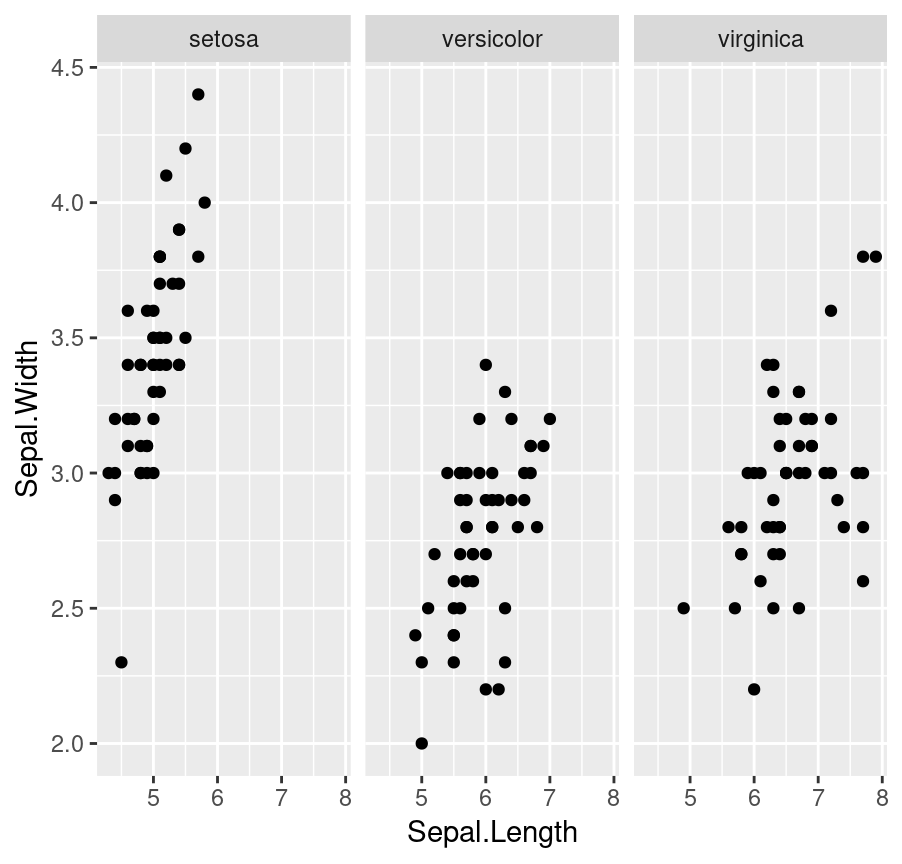

```r
ggplot(iris, aes(x=Sepal.Length, y=Sepal.Width))+
  geom_point() +
  facet_grid(. ~ Species)
```

## Playing with facet

[figure not shown]

```r
library(ggplot2)

ggplot(iris, aes(x=Sepal.Length, y=Sepal.Width))+
  geom_point() +
  facet_grid(. ~ Species)
```

## Playing with facet

Now, let’s level up the game a bit. Modify the `iris` dataset to get a more interesting visualization.

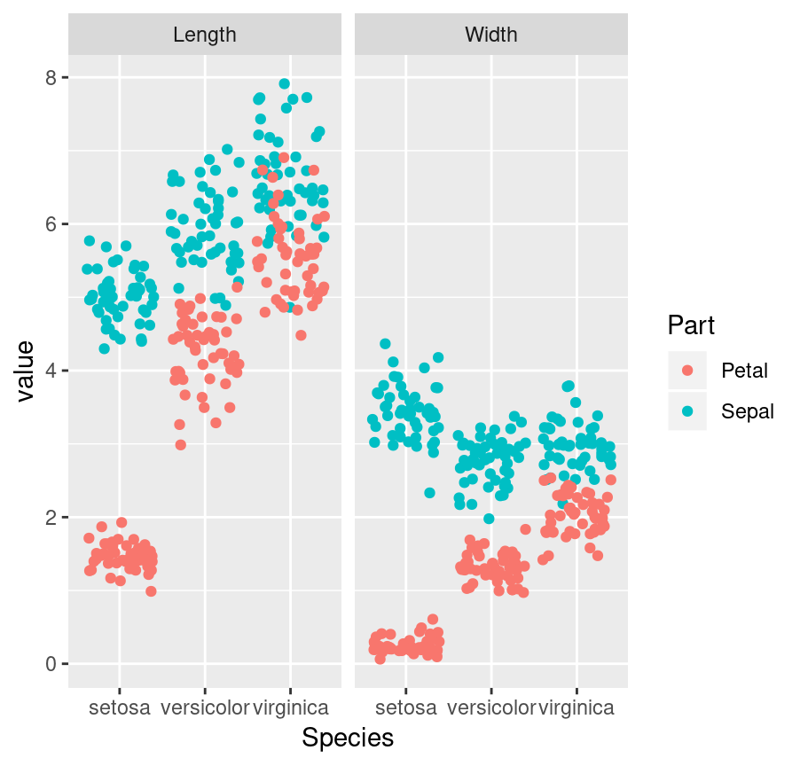

```r
library(tidyr)

iris %>%
  gather(key, value, -Species) %>%
  separate(key, c("Part","Measure"), sep="\\.") %>%
  ggplot(aes(x = Species, y = value, col = Part)) +
  geom_jitter() +
  facet_grid(. ~ Measure)
```

## Playing with facet

Give it another try!

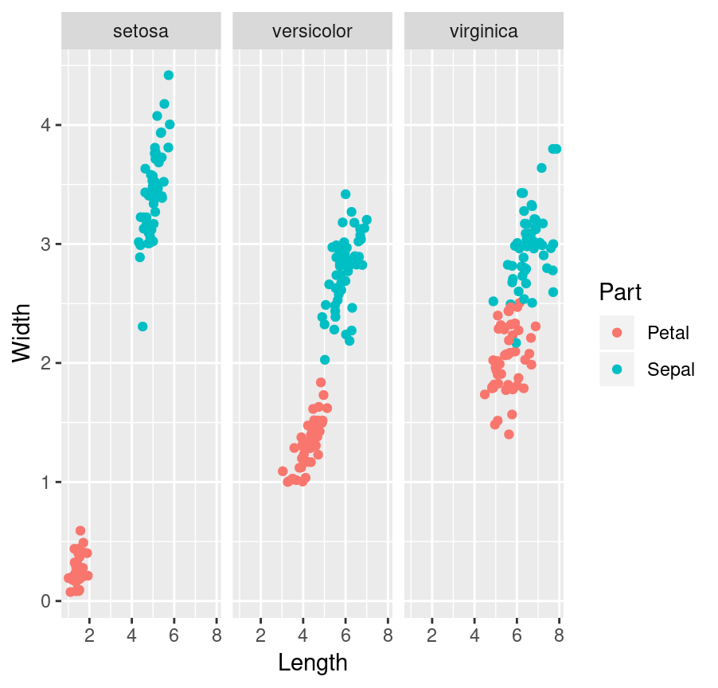

```r
library(tidyr)
library(dplyr)
library(ggplot2)

iris %>%
  mutate(Flower = 1:nrow(iris)) %>%
  gather(key, value, -Species, -Flower) %>%
  separate(key,c("Part", "Measure"),sep="\\.")%>%
  spread(Measure, value) %>%
  ggplot(aes(x=Length, y=Width, color=Part)) +
  geom_jitter() +
  facet_grid(. ~ Species)
```